# Latihan MPDW Pertemuan 4

Kaylila Kireinahana

2023-09-21

# White Noise

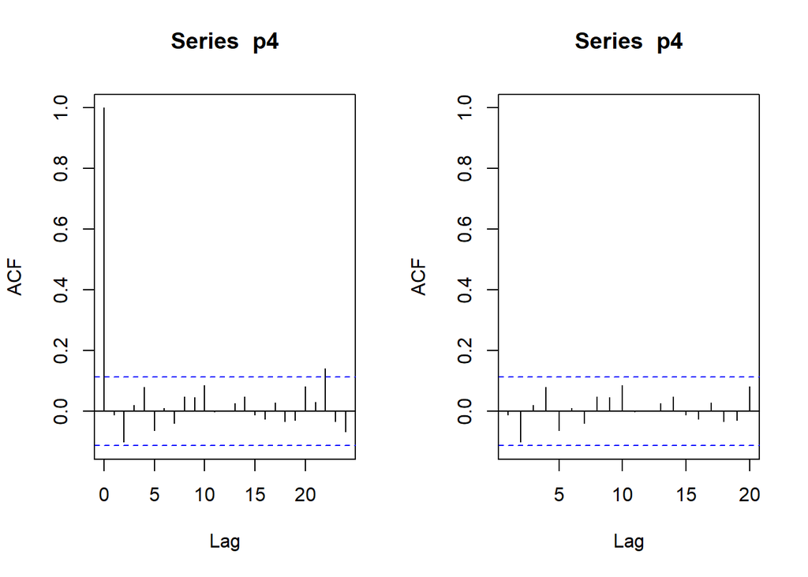

```r
par(mfrow = c(1, 2))
acf(p4)
acf(p4, xlim = c(1, 20))
```

# MA(2)

## Pembangkitan Proses MA(2)

```r
set.seed(1070)
p4.ma <- p4[1]
p4.ma[2] <- p4[2]
```

Rumus MA(2):
$$y_t=e_t+0.4e_{t-1}+0.6e_{t-2}$$

```r
for(i in 3:300){
   p4.ma[i] <- p4[i] + 0.4 * p4[i - 1] + 0.6 * p4[i - 2]
}
p4.ma
```

```
##   [1] -0.1325665997  1.2395283874 -0.2539000828 -1.3928630065 -1.5471681097
##   [6] -0.9583098712  0.1014963097 -1.3965610840  0.0136740575 -0.8331978846
##  [11]  0.9494872004 -1.0943060282 -1.1022404379 -1.0807554655 -0.7139777688
##  [16] -1.0383718743 -1.4255570107 -0.6487933955 -2.5332894106 -0.2343372826
##  [21] -1.8439843401  0.3033474894 -1.2017311697 -1.4360249252 -0.3029998762
##  [26]  1.0018857999  0.9982645166  2.9825340691  0.9936017174  1.3884119741
##  [31]  0.8133028407  0.7843020248 -1.0049292023  0.1985475559 -2.4578780794
##  [36] -1.3974476174 -2.2355016726 -1.1903450635  0.7729891897  0.1551125701
##  [41]  0.8772795604  1.2903003122  1.4095194731  1.4101426212 -0.3213634141
##  [46] -0.6410249885 -1.0173429319 -0.0231306557  0.7909806217  1.0827806381
##  [51]  2.1793432661  1.7198205686  0.8179396383  1.5080216250 -1.0521325435
##  [56]  0.3966141481 -0.6824617602 -0.0453669383 -0.2495909065  1.2769157393
##  [61]  0.7584931744  0.2646438748  0.5703565529  1.3342925483  0.4165435863
##  [66]  1.3325333096 -1.0334831504 -0.7587239678 -1.0712668963 -0.4056136754
##  [71]  0.6228134682  1.8039896240  1.2328425252  0.6686194749 -1.0375228761
```

[output cut: 45 more lines]

Atau menggunakan arima.sim:

```r
p4.ma1 <- arima.sim(list(order=c(0,0,2), ma=c(0.4,0.6)), n=300)
p4.ma1
```

```
## Time Series:
## Start = 1
## End = 300
## Frequency = 1
##   [1]  0.1977782451 -0.5380170695 -1.5706315393 -0.3450559932 -2.2495651083
##   [6] -0.0049331364 -2.2350094673  0.8950042425 -0.7584774614 -1.3431680812
##  [11] -2.0390968024 -1.3173976721 -0.1623828538  0.8999069005 -0.3199077284
##  [16]  1.8995113823  0.3713831406 -0.4257374195 -2.6644368533 -2.5332837577
##  [21] -1.5372752883 -1.7539635846  0.7149611036  1.7926744134  1.9156025671
##  [26]  0.0005712698  0.5258500448 -0.2666457869  1.4435274412  1.5435602636
##  [31]  2.5125626941  0.8768852783  0.7798003132 -0.7038620441  0.3198658591
##  [36]  0.9190235785  0.3682788038 -0.3939292368 -0.1984487432 -1.0676779046
##  [41] -0.9595554276 -3.7869708674 -1.7826290259 -0.5432193276  0.9622381901
##  [46] -0.5754972588  0.3712756568  0.4599343247  1.3241811002  0.7377347789
##  [51]  0.9788223122 -0.5001428475 -0.0902670638  0.2095098447 -0.2070612249
```

[output cut: 49 more lines]

## Karakteristik MA(2)

### Plot Time Series

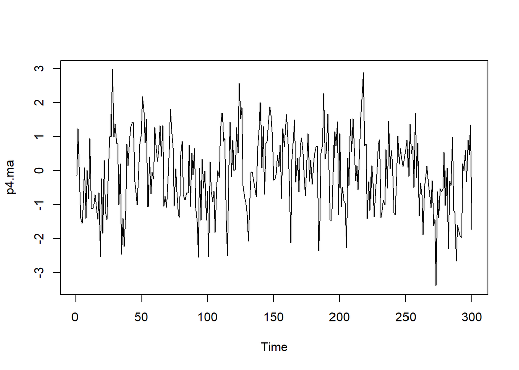

```r
ts.plot(p4.ma)
```

Berdasarkan plot time series, terlihat bahwa data MA(2) yang dibangkitkan stasioner dalam rataan

### Plot ACF

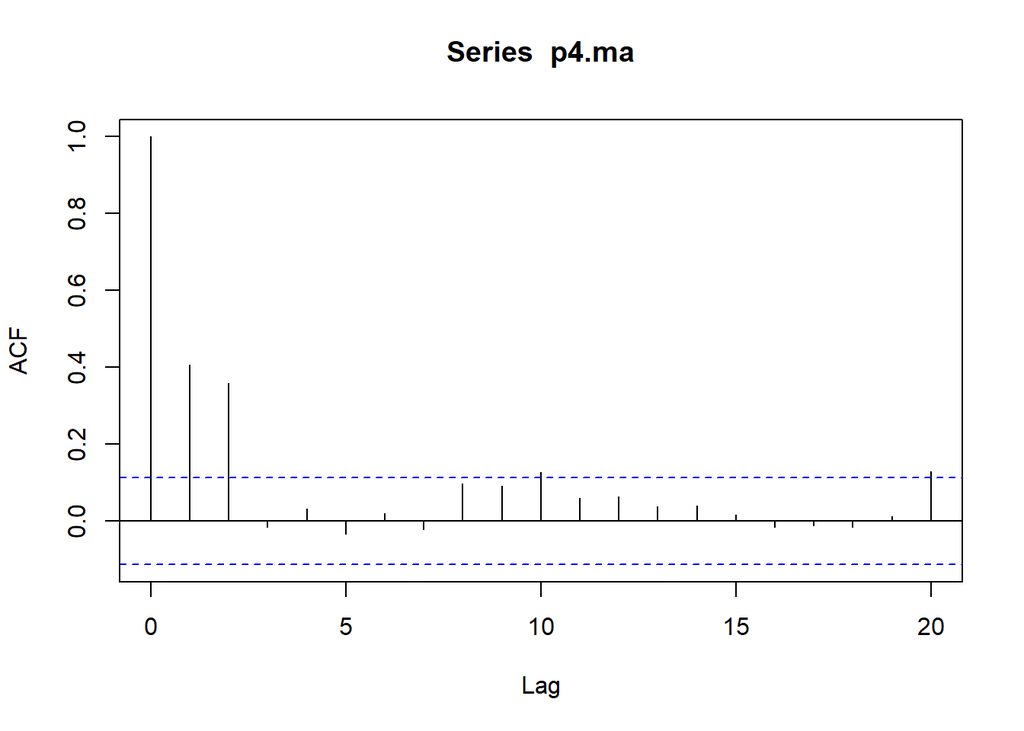

```r
acf(p4.ma,lag.max = 20)
```

Berdasarkan plot AFC tersebut, terlihat bahwa plot ACF *cuts off* di lag kedua.

### Plot PACF

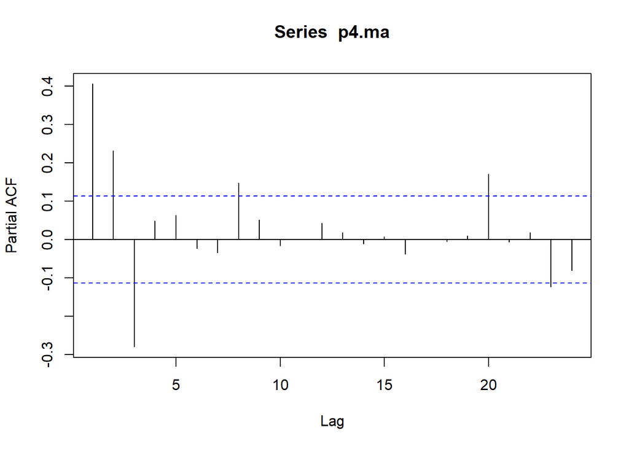

```r
pacf(p4.ma)
```

Berdasarkan plot PACF tersebut, terlihat bahwa plot PACF cenderung *tails off* dan membentuk gelombang sinus

### Plot EACF

```r
TSA::eacf(p4.ma)
```

```
## AR/MA
##   0 1 2 3 4 5 6 7 8 9 10 11 12 13
## 0 x x o o o o o o o x o  o  o  o
## 1 x x x o o o o o o o o  o  o  o
## 2 x x x o o o o o o o o  o  o  o
## 3 x x o x o o o o o o o  o  o  o
## 4 x x o o o o o o o o o  o  o  o
## 5 x x o o o o o o o o o  o  o  o
## 6 x x x o x x o x o o o  o  o  o
## 7 x x x x x x x x o o o  o  o  o
```

### Scatterplot Antar Peubah

#### $Y_t$ dengan $Y_{t-1}$

```r
#Yt
p4.yt_ma <- p4.ma[-1]
p4.yt_ma
```

```
##   [1]  1.2395283874 -0.2539000828 -1.3928630065 -1.5471681097 -0.9583098712
##   [6]  0.1014963097 -1.3965610840  0.0136740575 -0.8331978846  0.9494872004
##  [11] -1.0943060282 -1.1022404379 -1.0807554655 -0.7139777688 -1.0383718743
##  [16] -1.4255570107 -0.6487933955 -2.5332894106 -0.2343372826 -1.8439843401
##  [21]  0.3033474894 -1.2017311697 -1.4360249252 -0.3029998762  1.0018857999
##  [26]  0.9982645166  2.9825340691  0.9936017174  1.3884119741  0.8133028407
##  [31]  0.7843020248 -1.0049292023  0.1985475559 -2.4578780794 -1.3974476174
##  [36] -2.2355016726 -1.1903450635  0.7729891897  0.1551125701  0.8772795604
##  [41]  1.2903003122  1.4095194731  1.4101426212 -0.3213634141 -0.6410249885
##  [46] -1.0173429319 -0.0231306557  0.7909806217  1.0827806381  2.1793432661
##  [51]  1.7198205686  0.8179396383  1.5080216250 -1.0521325435  0.3966141481
##  [56] -0.6824617602 -0.0453669383 -0.2495909065  1.2769157393  0.7584931744
##  [61]  0.2646438748  0.5703565529  1.3342925483  0.4165435863  1.3325333096
##  [66] -1.0334831504 -0.7587239678 -1.0712668963 -0.4056136754  0.6228134682
##  [71]  1.8039896240  1.2328425252  0.6686194749 -1.0375228761  0.0658060974
```

[output cut: 45 more lines]

```r
#Yt-1
p4.yt_1_ma <- p4.ma[-300]
p4.yt_1_ma
```

```
##   [1] -0.1325665997  1.2395283874 -0.2539000828 -1.3928630065 -1.5471681097
##   [6] -0.9583098712  0.1014963097 -1.3965610840  0.0136740575 -0.8331978846
##  [11]  0.9494872004 -1.0943060282 -1.1022404379 -1.0807554655 -0.7139777688
##  [16] -1.0383718743 -1.4255570107 -0.6487933955 -2.5332894106 -0.2343372826
##  [21] -1.8439843401  0.3033474894 -1.2017311697 -1.4360249252 -0.3029998762
##  [26]  1.0018857999  0.9982645166  2.9825340691  0.9936017174  1.3884119741
##  [31]  0.8133028407  0.7843020248 -1.0049292023  0.1985475559 -2.4578780794
##  [36] -1.3974476174 -2.2355016726 -1.1903450635  0.7729891897  0.1551125701
##  [41]  0.8772795604  1.2903003122  1.4095194731  1.4101426212 -0.3213634141
##  [46] -0.6410249885 -1.0173429319 -0.0231306557  0.7909806217  1.0827806381
##  [51]  2.1793432661  1.7198205686  0.8179396383  1.5080216250 -1.0521325435
##  [56]  0.3966141481 -0.6824617602 -0.0453669383 -0.2495909065  1.2769157393
##  [61]  0.7584931744  0.2646438748  0.5703565529  1.3342925483  0.4165435863
##  [66]  1.3325333096 -1.0334831504 -0.7587239678 -1.0712668963 -0.4056136754
##  [71]  0.6228134682  1.8039896240  1.2328425252  0.6686194749 -1.0375228761
```

[output cut: 45 more lines]

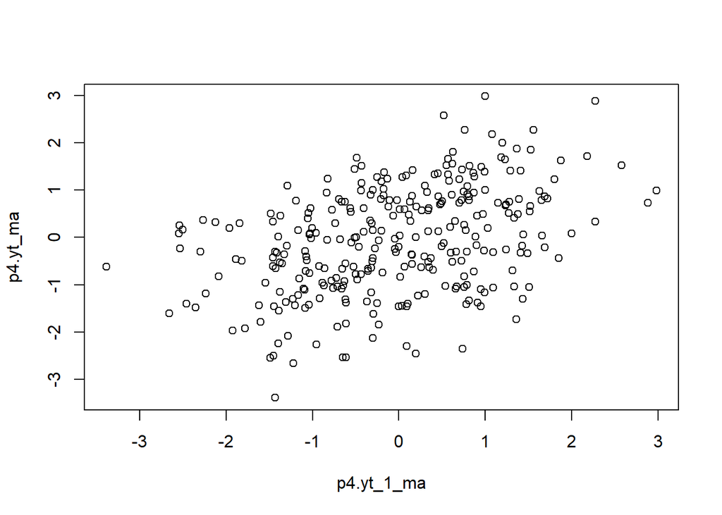

```r
plot(y=p4.yt_ma,x=p4.yt_1_ma)
```

Berdasarkan scatterplot tersebut, terlihat bahwa terdapat hubungan positif antara $Y_t$ dengan $Y_{t-1}$. Hal ini sesuai dengan teori yang ada

```r
cor(p4.yt_ma,p4.yt_1_ma)
```

```
## [1] 0.4072633
```

#### $Y_t$ dengan $Y_{t-2}$

```r
#Yt
p4.yt_ma2 <- p4.ma[-c(1,2)]
p4.yt_ma2
```

```
##   [1] -0.2539000828 -1.3928630065 -1.5471681097 -0.9583098712  0.1014963097
##   [6] -1.3965610840  0.0136740575 -0.8331978846  0.9494872004 -1.0943060282
##  [11] -1.1022404379 -1.0807554655 -0.7139777688 -1.0383718743 -1.4255570107
##  [16] -0.6487933955 -2.5332894106 -0.2343372826 -1.8439843401  0.3033474894
##  [21] -1.2017311697 -1.4360249252 -0.3029998762  1.0018857999  0.9982645166
##  [26]  2.9825340691  0.9936017174  1.3884119741  0.8133028407  0.7843020248
##  [31] -1.0049292023  0.1985475559 -2.4578780794 -1.3974476174 -2.2355016726
##  [36] -1.1903450635  0.7729891897  0.1551125701  0.8772795604  1.2903003122
##  [41]  1.4095194731  1.4101426212 -0.3213634141 -0.6410249885 -1.0173429319
##  [46] -0.0231306557  0.7909806217  1.0827806381  2.1793432661  1.7198205686
##  [51]  0.8179396383  1.5080216250 -1.0521325435  0.3966141481 -0.6824617602
##  [56] -0.0453669383 -0.2495909065  1.2769157393  0.7584931744  0.2646438748
##  [61]  0.5703565529  1.3342925483  0.4165435863  1.3325333096 -1.0334831504
##  [66] -0.7587239678 -1.0712668963 -0.4056136754  0.6228134682  1.8039896240
##  [71]  1.2328425252  0.6686194749 -1.0375228761  0.0658060974 -0.6213943543
```

[output cut: 45 more lines]

```r
#Yt-2
p4.yt_2_ma <- p4.ma[-c(299,300)]
p4.yt_2_ma
```

```
##   [1] -0.1325665997  1.2395283874 -0.2539000828 -1.3928630065 -1.5471681097
##   [6] -0.9583098712  0.1014963097 -1.3965610840  0.0136740575 -0.8331978846
##  [11]  0.9494872004 -1.0943060282 -1.1022404379 -1.0807554655 -0.7139777688
##  [16] -1.0383718743 -1.4255570107 -0.6487933955 -2.5332894106 -0.2343372826
##  [21] -1.8439843401  0.3033474894 -1.2017311697 -1.4360249252 -0.3029998762
##  [26]  1.0018857999  0.9982645166  2.9825340691  0.9936017174  1.3884119741
##  [31]  0.8133028407  0.7843020248 -1.0049292023  0.1985475559 -2.4578780794
##  [36] -1.3974476174 -2.2355016726 -1.1903450635  0.7729891897  0.1551125701
##  [41]  0.8772795604  1.2903003122  1.4095194731  1.4101426212 -0.3213634141
##  [46] -0.6410249885 -1.0173429319 -0.0231306557  0.7909806217  1.0827806381
##  [51]  2.1793432661  1.7198205686  0.8179396383  1.5080216250 -1.0521325435
##  [56]  0.3966141481 -0.6824617602 -0.0453669383 -0.2495909065  1.2769157393
##  [61]  0.7584931744  0.2646438748  0.5703565529  1.3342925483  0.4165435863
##  [66]  1.3325333096 -1.0334831504 -0.7587239678 -1.0712668963 -0.4056136754
##  [71]  0.6228134682  1.8039896240  1.2328425252  0.6686194749 -1.0375228761
```

[output cut: 45 more lines]

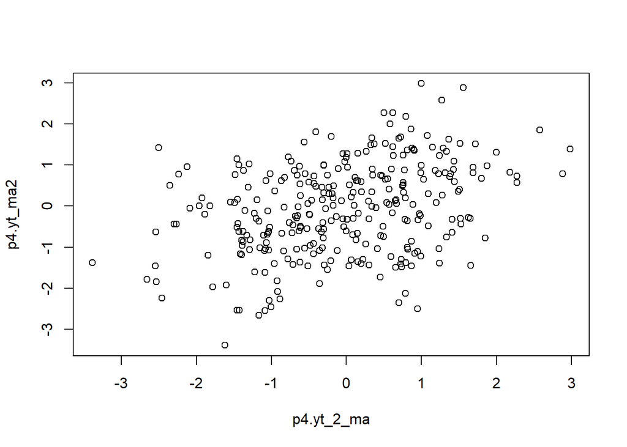

```r
plot(y=p4.yt_ma2,x=p4.yt_2_ma)
```

Berdasarkan scatterplot tersebut, terlihat bahwa terdapat hubungan positif antara $Y_t$ dengan $Y_{t-2}$. Hal ini sesuai dengan teori yang ada

```r
cor(p4.yt_ma2,p4.yt_2_ma)
```

```
## [1] 0.3615916
```

#### $Y_t$ dengan $Y_{t-3}$

```r
p4.yt_ma3 <- p4.ma[-c(1,2,3)]
p4.yt_ma3
```

```
##   [1] -1.3928630065 -1.5471681097 -0.9583098712  0.1014963097 -1.3965610840
##   [6]  0.0136740575 -0.8331978846  0.9494872004 -1.0943060282 -1.1022404379
##  [11] -1.0807554655 -0.7139777688 -1.0383718743 -1.4255570107 -0.6487933955
##  [16] -2.5332894106 -0.2343372826 -1.8439843401  0.3033474894 -1.2017311697
##  [21] -1.4360249252 -0.3029998762  1.0018857999  0.9982645166  2.9825340691
##  [26]  0.9936017174  1.3884119741  0.8133028407  0.7843020248 -1.0049292023
##  [31]  0.1985475559 -2.4578780794 -1.3974476174 -2.2355016726 -1.1903450635
##  [36]  0.7729891897  0.1551125701  0.8772795604  1.2903003122  1.4095194731
##  [41]  1.4101426212 -0.3213634141 -0.6410249885 -1.0173429319 -0.0231306557
##  [46]  0.7909806217  1.0827806381  2.1793432661  1.7198205686  0.8179396383
##  [51]  1.5080216250 -1.0521325435  0.3966141481 -0.6824617602 -0.0453669383
##  [56] -0.2495909065  1.2769157393  0.7584931744  0.2646438748  0.5703565529
##  [61]  1.3342925483  0.4165435863  1.3325333096 -1.0334831504 -0.7587239678
##  [66] -1.0712668963 -0.4056136754  0.6228134682  1.8039896240  1.2328425252
##  [71]  0.6686194749 -1.0375228761  0.0658060974 -0.6213943543 -1.3098142061
```

[output cut: 45 more lines]

```r
#Yt-2
p4.yt_3_ma <- p4.ma[-c(298,299,300)]
p4.yt_3_ma
```

```
##   [1] -0.1325665997  1.2395283874 -0.2539000828 -1.3928630065 -1.5471681097
##   [6] -0.9583098712  0.1014963097 -1.3965610840  0.0136740575 -0.8331978846
##  [11]  0.9494872004 -1.0943060282 -1.1022404379 -1.0807554655 -0.7139777688
##  [16] -1.0383718743 -1.4255570107 -0.6487933955 -2.5332894106 -0.2343372826
##  [21] -1.8439843401  0.3033474894 -1.2017311697 -1.4360249252 -0.3029998762
##  [26]  1.0018857999  0.9982645166  2.9825340691  0.9936017174  1.3884119741
##  [31]  0.8133028407  0.7843020248 -1.0049292023  0.1985475559 -2.4578780794
##  [36] -1.3974476174 -2.2355016726 -1.1903450635  0.7729891897  0.1551125701
##  [41]  0.8772795604  1.2903003122  1.4095194731  1.4101426212 -0.3213634141
##  [46] -0.6410249885 -1.0173429319 -0.0231306557  0.7909806217  1.0827806381
##  [51]  2.1793432661  1.7198205686  0.8179396383  1.5080216250 -1.0521325435
##  [56]  0.3966141481 -0.6824617602 -0.0453669383 -0.2495909065  1.2769157393
##  [61]  0.7584931744  0.2646438748  0.5703565529  1.3342925483  0.4165435863
##  [66]  1.3325333096 -1.0334831504 -0.7587239678 -1.0712668963 -0.4056136754
##  [71]  0.6228134682  1.8039896240  1.2328425252  0.6686194749 -1.0375228761
```

[output cut: 45 more lines]

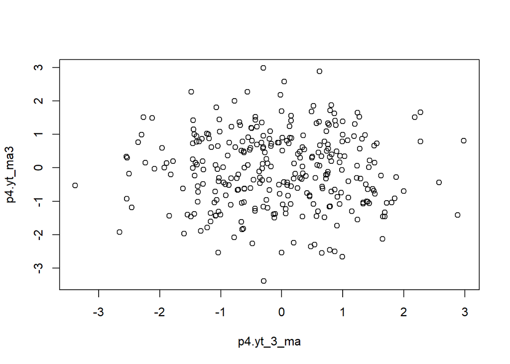

```r
plot(y=p4.yt_ma3,x=p4.yt_3_ma)
```

Berdasarkan scatterplot tersebut, terlihat bahwa cenderung tidak terdapat hubungan antara $Y_t$ dengan $Y_{t-3}$.

```r
cor(p4.yt_ma3,p4.yt_3_ma)
```

```
## [1] -0.01529536
```

Korelasi antara $Y_t$ dengan $Y_{t-3}$ hasil simulasi mendekati teori yang ada yaitu 0.

# AR(2)

## Pembangkitan Data Manual

Akan dicoba membangkitkan proses AR, yaitu AR(2) dengan $\phi_{1} = 0.5$ dan $\phi_2=0.2$ sebanyak 300 observasi dan $c=0$.

```r
set.seed(1070)
```

Bentuk loop dapat dilihat dari rumus AR(2) yang hendak dibangkitkan:

$Y_t=e_t+0.5Y_{t-1}+0.2Y_{t-2}$

```r
p4.n<-length(p4)
p4.n
```

```
## [1] 300
```

```r
p4.ar <- c(1:p4.n)
for (i in 3:p4.n) {p4.ar[i]<-p4[i]+0.5*p4[i-1]+0.2*p4[i-2]}
p4.ar
```

```
##   [1]  1.000000000  2.000000000 -0.076920604 -1.955691509 -1.465950663
##   [6] -0.250671356  0.292746693 -1.504170767 -0.238286932 -0.107855840
##  [11]  0.721737565 -1.010183527 -1.488465140 -0.649240718 -0.322028218
##  [16] -1.093156134 -1.457059117 -0.330528948 -2.136350461 -0.577883114
##  [21] -0.954847342  0.063156668 -0.871208555 -1.665631591 -0.072380803
##  [26]  1.591512153  0.845431062  2.388963771  1.221677509  0.559670380
##  [31]  0.749354513  0.833091806 -1.232967052 -0.153724903 -1.758319949
##  [36] -1.791114224 -1.654363438 -0.851171513  1.063802992  0.388719864
##  [41]  0.315663943  1.400465111  1.480541131  0.940466901 -0.598899648
##  [46] -0.844398453 -0.705028939  0.128643528  0.947506660  1.017456037
##  [51]  1.903443299  1.654197388  0.309973642  1.144447669 -0.778297056
##  [56] -0.203197578 -0.146323930 -0.126826870 -0.270241621  1.327239669
##  [61]  0.978281968 -0.288382979  0.382761136  1.692324933  0.291174516
##  [66]  0.675798846 -0.728932027 -1.122865378 -0.770820143 -0.110944633
##  [71]  0.712623190  1.815791127  1.105509666  0.114160120 -1.165614481
```

[output cut: 45 more lines]

## Pembangkitan Data melalui arima.sim

```r
p4.ar1 <- arima.sim(list(order=c(2,0,0), ar=c(0.5,0.2)), n=300)
p4.ar1
```

```
## Time Series:
## Start = 1
## End = 300
## Frequency = 1
##   [1]  1.400142642  0.972753841 -0.623637095  0.757841244  0.471529333
##   [6]  1.218860490  1.784283667  2.717341059  1.311513157  1.191774470
##  [11]  0.399716414  0.945938533  1.543930026  0.628389273 -0.232453702
##  [16]  0.352834066 -0.561844230 -1.099232358 -3.678342756 -2.101777550
##  [21] -0.502858135 -0.197370244 -1.734739256 -0.206023617  0.650936145
##  [26]  0.747594092  0.395849274  1.091521322 -0.107962478 -0.079233561
##  [31]  0.685458999 -0.032711796 -0.479476140 -1.050166358 -0.330700886
##  [36] -2.107832510 -1.835185337 -1.765212634 -2.542167375 -1.246161002
##  [41] -1.376583578 -1.299210625  0.061627639 -1.030290324  0.006876374
##  [46]  1.072202329  0.255336193  0.817218154  0.063029520  0.701369705
##  [51]  1.157924813 -0.762925419  0.307161268 -1.593044389 -1.664415781
```

[output cut: 49 more lines]

## Karakteristik AR(2)

### Plot Time Series

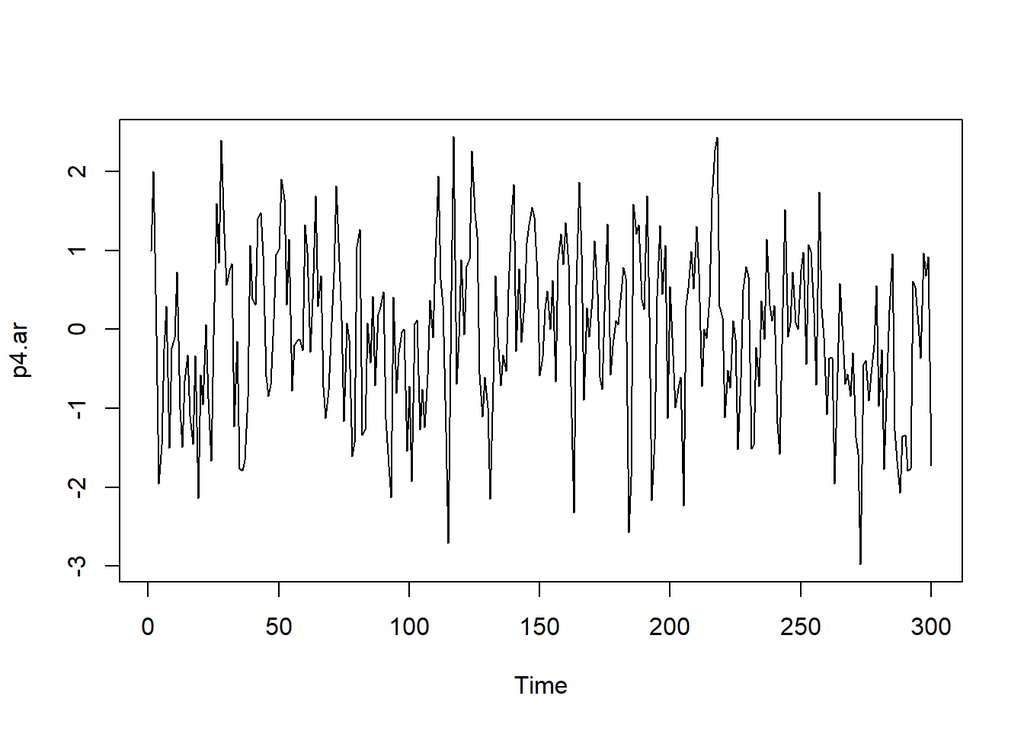

```r
ts.plot(p4.ar)
```

Berdasarkan plot time series tersebut terlihat bahwa data cenderung stasioner pada rataan.

### Plot ACF

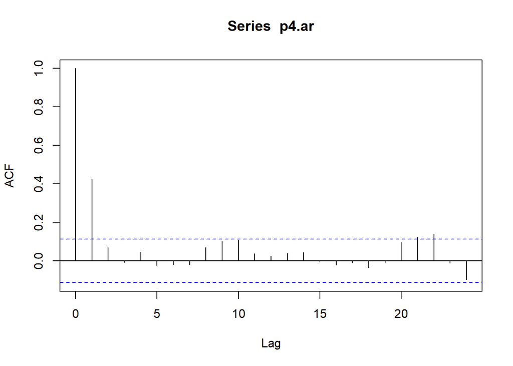

```r
acf(p4.ar)
```

Berdasarkan plot ACF tersebut terlihat bahwa plot ACF cenderung *tails off* dan cenderung membentuk pola grafik sinus

### Plot PACF

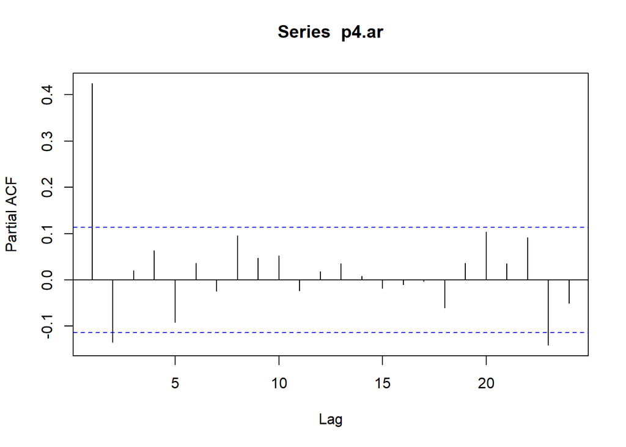

```r
pacf(p4.ar)
```

### Plot EACF

```r
TSA::eacf(p4.ar)
```

```
## AR/MA
##   0 1 2 3 4 5 6 7 8 9 10 11 12 13
## 0 x o o o o o o o o o o  o  o  o
## 1 x x o o o o o o o o o  o  o  o
## 2 x o x o o o o o o o o  o  o  o
## 3 x x o x o o o o o o o  o  o  o
## 4 x x x o x o o o o o o  o  o  o
## 5 x x x o x o o o o o o  o  o  o
## 6 x o x o x o o o o o o  o  o  o
## 7 x x x o o o o o o o o  o  o  o
```

### Scatterplot Antar Peubah

#### $Y_t$ dengan $Y_{t-1}$

```r
#Yt
p4.yt_ar <- p4.ar[-1]
p4.yt_ar
```

```
##   [1]  2.000000000 -0.076920604 -1.955691509 -1.465950663 -0.250671356
##   [6]  0.292746693 -1.504170767 -0.238286932 -0.107855840  0.721737565
##  [11] -1.010183527 -1.488465140 -0.649240718 -0.322028218 -1.093156134
##  [16] -1.457059117 -0.330528948 -2.136350461 -0.577883114 -0.954847342
##  [21]  0.063156668 -0.871208555 -1.665631591 -0.072380803  1.591512153
##  [26]  0.845431062  2.388963771  1.221677509  0.559670380  0.749354513
##  [31]  0.833091806 -1.232967052 -0.153724903 -1.758319949 -1.791114224
##  [36] -1.654363438 -0.851171513  1.063802992  0.388719864  0.315663943
##  [41]  1.400465111  1.480541131  0.940466901 -0.598899648 -0.844398453
##  [46] -0.705028939  0.128643528  0.947506660  1.017456037  1.903443299
##  [51]  1.654197388  0.309973642  1.144447669 -0.778297056 -0.203197578
##  [56] -0.146323930 -0.126826870 -0.270241621  1.327239669  0.978281968
##  [61] -0.288382979  0.382761136  1.692324933  0.291174516  0.675798846
##  [66] -0.728932027 -1.122865378 -0.770820143 -0.110944633  0.712623190
##  [71]  1.815791127  1.105509666  0.114160120 -1.165614481  0.078518275
```

[output cut: 45 more lines]

```r
#Yt-1
p4.yt_1_ar <- p4.ar[-300]
p4.yt_1_ar
```

```
##   [1]  1.000000000  2.000000000 -0.076920604 -1.955691509 -1.465950663
##   [6] -0.250671356  0.292746693 -1.504170767 -0.238286932 -0.107855840
##  [11]  0.721737565 -1.010183527 -1.488465140 -0.649240718 -0.322028218
##  [16] -1.093156134 -1.457059117 -0.330528948 -2.136350461 -0.577883114
##  [21] -0.954847342  0.063156668 -0.871208555 -1.665631591 -0.072380803
##  [26]  1.591512153  0.845431062  2.388963771  1.221677509  0.559670380
##  [31]  0.749354513  0.833091806 -1.232967052 -0.153724903 -1.758319949
##  [36] -1.791114224 -1.654363438 -0.851171513  1.063802992  0.388719864
##  [41]  0.315663943  1.400465111  1.480541131  0.940466901 -0.598899648
##  [46] -0.844398453 -0.705028939  0.128643528  0.947506660  1.017456037
##  [51]  1.903443299  1.654197388  0.309973642  1.144447669 -0.778297056
##  [56] -0.203197578 -0.146323930 -0.126826870 -0.270241621  1.327239669
##  [61]  0.978281968 -0.288382979  0.382761136  1.692324933  0.291174516
##  [66]  0.675798846 -0.728932027 -1.122865378 -0.770820143 -0.110944633
##  [71]  0.712623190  1.815791127  1.105509666  0.114160120 -1.165614481
```

[output cut: 45 more lines]

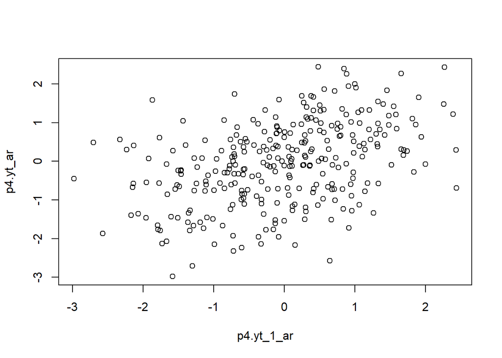

```r
plot(y=p4.yt_ar,x=p4.yt_1_ar)
```

Berdasarkan scatterplot tersebut, terlihat bahwa terdapat hubungan positif antara $Y_t$ dengan $Y_{t-1}$. Hal ini sesuai dengan teori yang ada

```r
cor(p4.yt_ar,p4.yt_1_ar)
```

```
## [1] 0.4262827
```

#### $Y_t$ dengan $Y_{t-2}$

```r
#Yt
p4.yt_ar2 <- p4.ar[-c(1,2)]
p4.yt_ar2
```

```
##   [1] -0.076920604 -1.955691509 -1.465950663 -0.250671356  0.292746693
##   [6] -1.504170767 -0.238286932 -0.107855840  0.721737565 -1.010183527
##  [11] -1.488465140 -0.649240718 -0.322028218 -1.093156134 -1.457059117
##  [16] -0.330528948 -2.136350461 -0.577883114 -0.954847342  0.063156668
##  [21] -0.871208555 -1.665631591 -0.072380803  1.591512153  0.845431062
##  [26]  2.388963771  1.221677509  0.559670380  0.749354513  0.833091806
##  [31] -1.232967052 -0.153724903 -1.758319949 -1.791114224 -1.654363438
##  [36] -0.851171513  1.063802992  0.388719864  0.315663943  1.400465111
##  [41]  1.480541131  0.940466901 -0.598899648 -0.844398453 -0.705028939
##  [46]  0.128643528  0.947506660  1.017456037  1.903443299  1.654197388
##  [51]  0.309973642  1.144447669 -0.778297056 -0.203197578 -0.146323930
##  [56] -0.126826870 -0.270241621  1.327239669  0.978281968 -0.288382979
##  [61]  0.382761136  1.692324933  0.291174516  0.675798846 -0.728932027
##  [66] -1.122865378 -0.770820143 -0.110944633  0.712623190  1.815791127
##  [71]  1.105509666  0.114160120 -1.165614481  0.078518275 -0.128034502
```

[output cut: 45 more lines]

```r
#Yt-2
p4.yt_2_ar <- p4.ar[-c(299,300)]
p4.yt_2_ar
```

```
##   [1]  1.000000000  2.000000000 -0.076920604 -1.955691509 -1.465950663
##   [6] -0.250671356  0.292746693 -1.504170767 -0.238286932 -0.107855840
##  [11]  0.721737565 -1.010183527 -1.488465140 -0.649240718 -0.322028218
##  [16] -1.093156134 -1.457059117 -0.330528948 -2.136350461 -0.577883114
##  [21] -0.954847342  0.063156668 -0.871208555 -1.665631591 -0.072380803
##  [26]  1.591512153  0.845431062  2.388963771  1.221677509  0.559670380
##  [31]  0.749354513  0.833091806 -1.232967052 -0.153724903 -1.758319949
##  [36] -1.791114224 -1.654363438 -0.851171513  1.063802992  0.388719864
##  [41]  0.315663943  1.400465111  1.480541131  0.940466901 -0.598899648
##  [46] -0.844398453 -0.705028939  0.128643528  0.947506660  1.017456037
##  [51]  1.903443299  1.654197388  0.309973642  1.144447669 -0.778297056
##  [56] -0.203197578 -0.146323930 -0.126826870 -0.270241621  1.327239669
##  [61]  0.978281968 -0.288382979  0.382761136  1.692324933  0.291174516
##  [66]  0.675798846 -0.728932027 -1.122865378 -0.770820143 -0.110944633
##  [71]  0.712623190  1.815791127  1.105509666  0.114160120 -1.165614481
```

[output cut: 45 more lines]

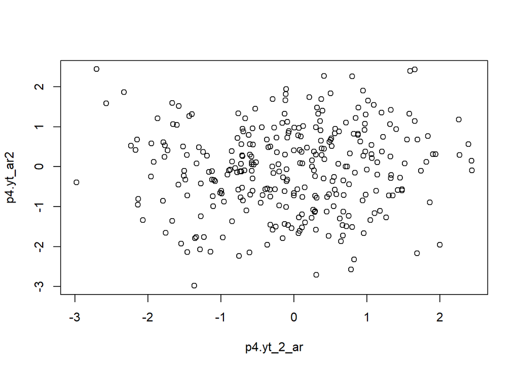

```r
plot(y=p4.yt_ar2,x=p4.yt_2_ar)
```

Berdasarkan scatterplot tersebut, terlihat bahwa cenderung tidak terdapat hubungan antara $Y_t$ dengan $Y_{t-2}$.

```r
cor(p4.yt_ar2,p4.yt_2_ar)
```

```
## [1] 0.06962334
```

Korelasi antara $Y_t$ dengan $Y_{t-2}$ hasil simulasi mendekati 0.

#### $Y_t$ dengan $Y_{t-3}$

```r
p4.yt_ar3 <- p4.ar[-c(1,2,3)]
p4.yt_ar3
```

```
##   [1] -1.955691509 -1.465950663 -0.250671356  0.292746693 -1.504170767
##   [6] -0.238286932 -0.107855840  0.721737565 -1.010183527 -1.488465140
##  [11] -0.649240718 -0.322028218 -1.093156134 -1.457059117 -0.330528948
##  [16] -2.136350461 -0.577883114 -0.954847342  0.063156668 -0.871208555
##  [21] -1.665631591 -0.072380803  1.591512153  0.845431062  2.388963771
##  [26]  1.221677509  0.559670380  0.749354513  0.833091806 -1.232967052
##  [31] -0.153724903 -1.758319949 -1.791114224 -1.654363438 -0.851171513
##  [36]  1.063802992  0.388719864  0.315663943  1.400465111  1.480541131
##  [41]  0.940466901 -0.598899648 -0.844398453 -0.705028939  0.128643528
##  [46]  0.947506660  1.017456037  1.903443299  1.654197388  0.309973642
##  [51]  1.144447669 -0.778297056 -0.203197578 -0.146323930 -0.126826870
##  [56] -0.270241621  1.327239669  0.978281968 -0.288382979  0.382761136
##  [61]  1.692324933  0.291174516  0.675798846 -0.728932027 -1.122865378
##  [66] -0.770820143 -0.110944633  0.712623190  1.815791127  1.105509666
##  [71]  0.114160120 -1.165614481  0.078518275 -0.128034502 -1.603247328
```

[output cut: 45 more lines]

```r
#Yt-2
p4.yt_3_ar <- p4.ar[-c(298,299,300)]
p4.yt_3_ar
```

```
##   [1]  1.000000000  2.000000000 -0.076920604 -1.955691509 -1.465950663
##   [6] -0.250671356  0.292746693 -1.504170767 -0.238286932 -0.107855840
##  [11]  0.721737565 -1.010183527 -1.488465140 -0.649240718 -0.322028218
##  [16] -1.093156134 -1.457059117 -0.330528948 -2.136350461 -0.577883114
##  [21] -0.954847342  0.063156668 -0.871208555 -1.665631591 -0.072380803
##  [26]  1.591512153  0.845431062  2.388963771  1.221677509  0.559670380
##  [31]  0.749354513  0.833091806 -1.232967052 -0.153724903 -1.758319949
##  [36] -1.791114224 -1.654363438 -0.851171513  1.063802992  0.388719864
##  [41]  0.315663943  1.400465111  1.480541131  0.940466901 -0.598899648
##  [46] -0.844398453 -0.705028939  0.128643528  0.947506660  1.017456037
##  [51]  1.903443299  1.654197388  0.309973642  1.144447669 -0.778297056
##  [56] -0.203197578 -0.146323930 -0.126826870 -0.270241621  1.327239669
##  [61]  0.978281968 -0.288382979  0.382761136  1.692324933  0.291174516
##  [66]  0.675798846 -0.728932027 -1.122865378 -0.770820143 -0.110944633
##  [71]  0.712623190  1.815791127  1.105509666  0.114160120 -1.165614481
```

[output cut: 45 more lines]

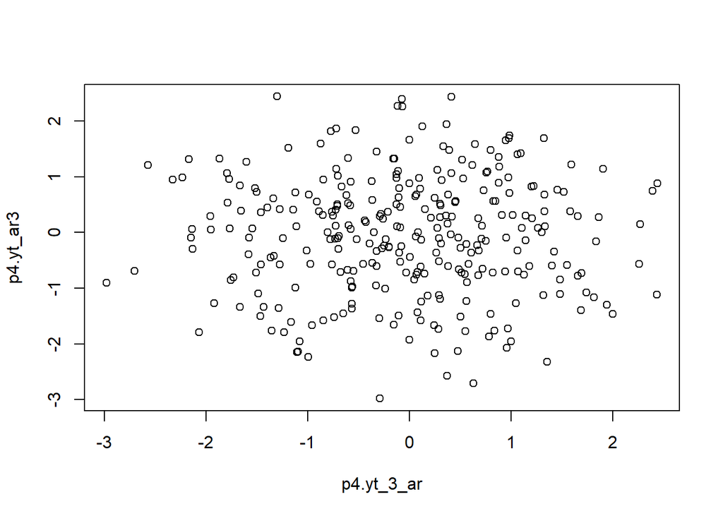

```r
plot(y=p4.yt_ar3,x=p4.yt_3_ar)
```

Berdasarkan scatterplot tersebut, terlihat bahwa cenderung tidak terdapat hubungan antara $Y_t$ dengan $Y_{t-3}$.

```r
cor(p4.yt_ar3,p4.yt_3_ar)
```

```
## [1] -0.008434546
```

Korelasi antara $Y_t$ dengan $Y_{t-3}$ hasil simulasi mendekati 0.

# ARMA(2,2)

## Fungsi Pembangkit ARMA

```r
set.seed(1070)
p4.coefs <- c(0.5, 0.2)
p4.e <- c(0.4, 0.6)

p4.coefs %*% p4.e
```

```
##      [,1]
## [1,] 0.32
```

```r
arma.sim <- function(n, macoef, arcoef){
  manum <- length(macoef)
  arnum <- length(arcoef)
  stopifnot(manum < n & arnum < n)

  wn <- rnorm(n, sd = 0.5)
  init <- max(manum, arnum)

  arma <- wn[1:init]
  for(i in {init+1}:n){
   mastart <- i - manum
   maend <- i-1
   arstart <- i - arnum
   arend <- i-1
   arma[i] <- sum(arcoef * arma[arstart:arend]) + sum(macoef * wn[mastart:maend])  + wn[i]
   }
  return(arma)
}
```

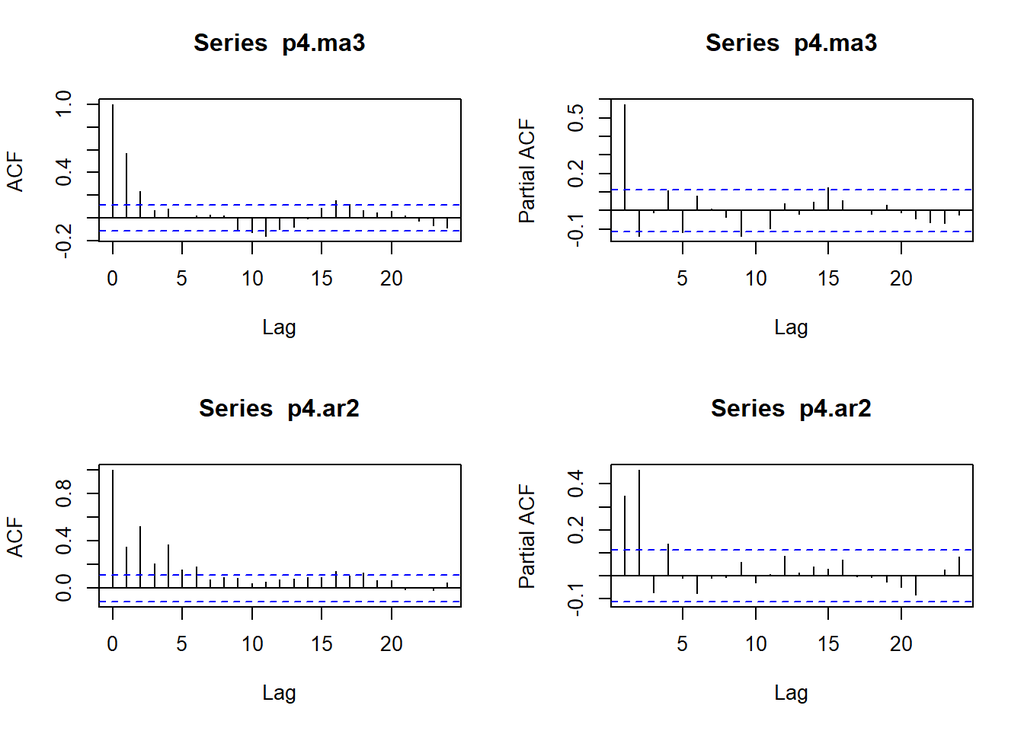

```r
# beberapa contoh pembangkitan melalui fungsi

p4.ma3 <- arma.sim(300, c(0.4, 0.6), 0)
p4.ar2 <- arma.sim(300, 0, c(0.5, 0.2))

par(mfrow = c(2, 2))
acf(p4.ma3)
pacf(p4.ma3)
acf(p4.ar2)
pacf(p4.ar2)
```

```r
#contoh untuk ARMA
p4.arma22 <- arma.sim(300, c(0.5, 0.2), c(0.4,0.6))

p4.arma22 |> arima(c(2,0,2))
```

```
##
## Call:
## arima(x = p4.arma22, order = c(2, 0, 2))
##
## Coefficients:
##          ar1     ar2     ma1     ma2  intercept
##       0.8065  0.1619  0.0260  0.4879    -3.9135
## s.e.  0.1382  0.1386  0.1266  0.0561     1.1809
##
## sigma^2 estimated as 0.2274:  log likelihood = -205.53,  aic = 423.06
```

```r
set.seed(1070)
p4.n2 = length(p4)
p4.phi1 = 0.5
p4.phi2 = 0.2
p4.theta1 = 0.4
p4.theta2 = 0.6

p4.y.arma=c(1:p4.n2)
for (i in 3:p4.n2){p4.y.arma[i] = p4.phi1*p4.y.arma[i-1] + p4.phi2*p4.y.arma[i-2]+ p4.theta1*p4[i-1] + p4.theta2*p4[i-2] + p4[i]}
```

```r
p4.arma11 <- arima.sim(list(order=c(2,0,2), ar = c(0.5,0.2), ma = c(0.4,0.6)), n=300)
p4.arma11
```

```
## Time Series:
## Start = 1
## End = 300
## Frequency = 1
##   [1]  0.6056187577  1.0920911072  0.4005235183  1.8622074218  2.5547686781
##   [6]  4.1623885176  3.4690332727  3.3467946531  1.6633419370  1.8208957582
##  [11]  2.1621398450  1.8135278780  0.9452626712  0.6368881680 -0.5601812864
##  [16] -1.1122684372 -4.4551413433 -4.2326533850 -3.5505742888 -1.6595796313
##  [21] -2.1154019323 -1.0183412356 -0.4723166796  0.8843545133  1.0854486996
##  [26]  1.6984175647  0.5661556748  0.5324942865  0.5889881229  0.1939316939
##  [31] -0.0812854382 -1.2615838763 -1.0384531015 -2.8702126708 -2.8767388658
##  [36] -3.7639862701 -4.3493636272 -3.3221555297 -3.4003484019 -2.5975406557
##  [41] -1.2840067565 -1.7851656419 -0.3682631716  0.4567786849  0.6883429489
##  [46]  1.5626740290  0.5431184972  1.2169124052  1.4762904064  0.1210663290
##  [51]  0.6967459877 -1.9279351337 -2.1173367764 -2.5878869784 -1.7759151721
```

[output cut: 49 more lines]

## Karakteristik ARMA(2,2)

### Plot Time Series

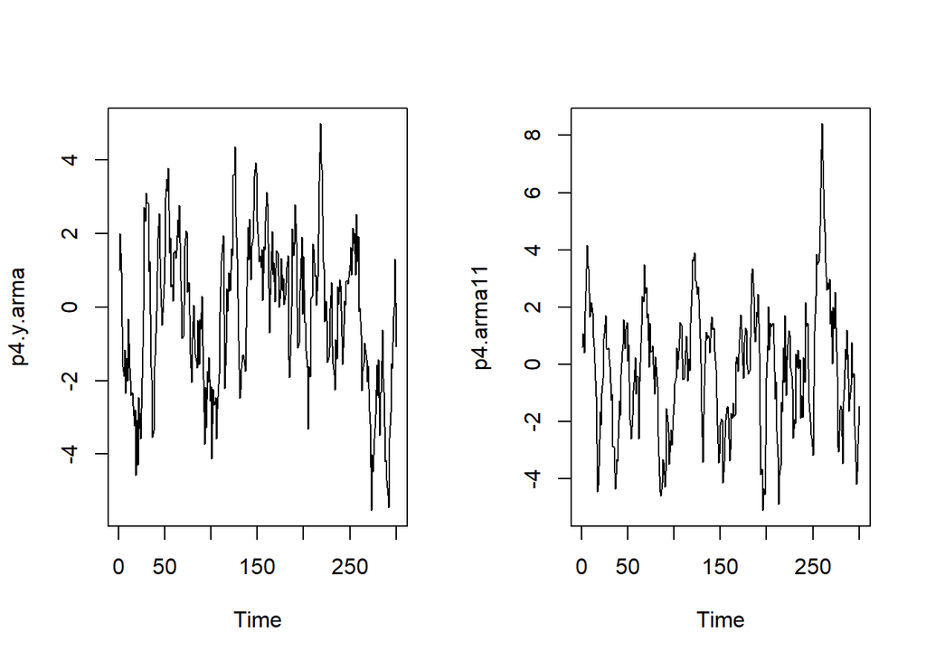

```r
par(mfrow = c(1, 2))
ts.plot(p4.y.arma)
ts.plot(p4.arma11)
```

```r
par(mfrow = c(1, 1))
```

### Plot ACF

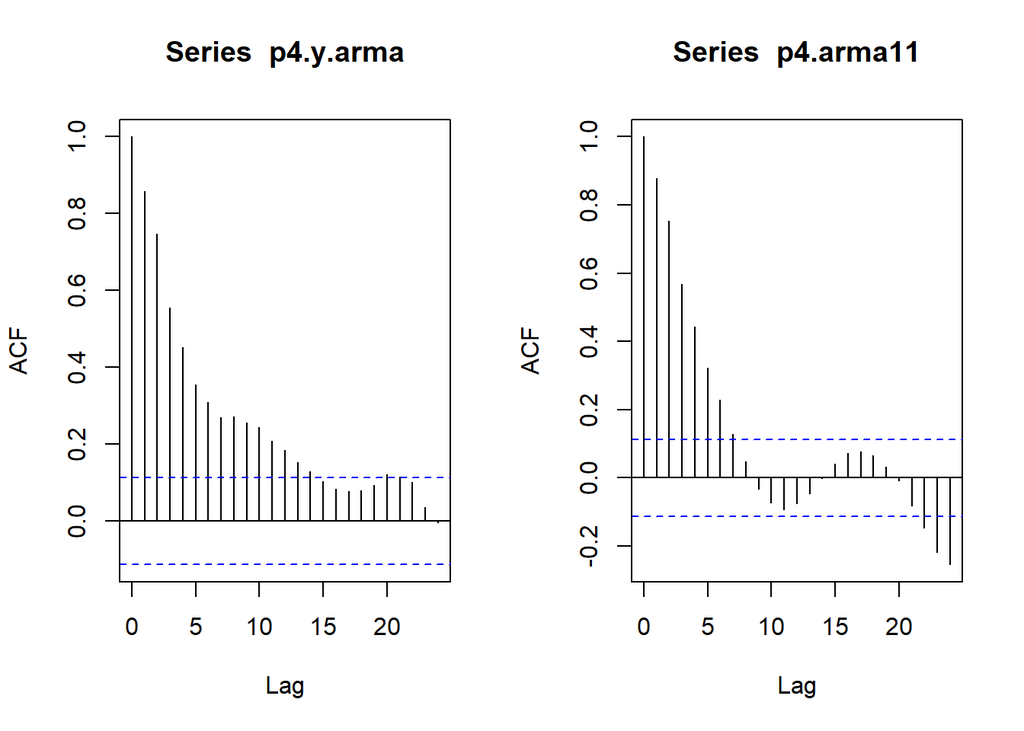

```r
par(mfrow = c(1, 2))
acf(p4.y.arma)
acf(p4.arma11)
```

```r
par(mfrow = c(1, 1))
```

Berdasarkan plot ACF tersebut, terlihat bahwa model ARMA(2,2) hasil simulasi memiliki plot ACF yang *tails off*.

### Plot PACF

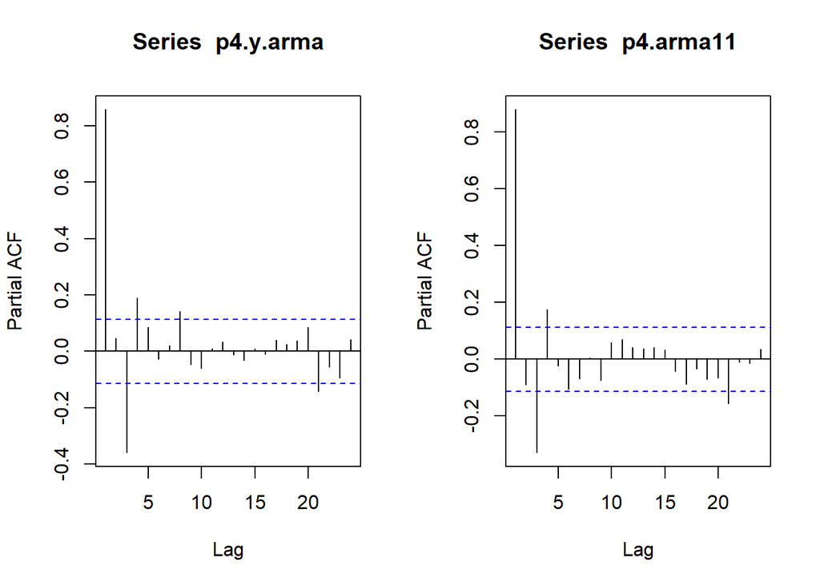

```r
par(mfrow = c(1, 2))
pacf(p4.y.arma)
pacf(p4.arma11)
```

```r
par(mfrow = c(1, 1))
```

Berdasarkan plot PACF tersebut, terlihat bahwa model ARMA(2,2) hasil simulasi memiliki plot PACF yang *cuts off*,

### Plot EACF

```r
TSA::eacf(p4.y.arma)
```

```
## AR/MA
##   0 1 2 3 4 5 6 7 8 9 10 11 12 13
## 0 x x x x x x x x x x x  x  x  x
## 1 o x x o x o x o o o o  o  o  o
## 2 x x o o x o x o o o o  o  o  o
## 3 x x o x o o x o o o o  o  o  o
## 4 x x x x o o x o o o o  o  o  o
## 5 x o o x x x o o o o o  o  o  o
## 6 x o x x x x o o o o o  o  o  o
## 7 x x x x x x o x o o o  o  o  o
```

```r
TSA::eacf(p4.arma11)
```

```
## AR/MA
##   0 1 2 3 4 5 6 7 8 9 10 11 12 13
## 0 x x x x x x x o o o o  o  o  o
## 1 o x o x o x o o o o x  o  o  o
## 2 x x x x o x o x x o o  o  o  o
## 3 x x x o o o o x o o o  o  o  o
## 4 x x x x x o o x o o o  o  o  o
## 5 x x o x x o o x o o o  o  o  o
## 6 x x o o x o x o o o o  o  o  o
## 7 o x o x x o o x o o o  o  o  o
```

### Scatterplot Antar Peubah

#### $Y_t$ dengan $Y_{t-1}$

```r
#Yt
p4.yt_arma <- p4.arma11[-1]
p4.yt_arma
```

```
##   [1]  1.0920911072  0.4005235183  1.8622074218  2.5547686781  4.1623885176
##   [6]  3.4690332727  3.3467946531  1.6633419370  1.8208957582  2.1621398450
##  [11]  1.8135278780  0.9452626712  0.6368881680 -0.5601812864 -1.1122684372
##  [16] -4.4551413433 -4.2326533850 -3.5505742888 -1.6595796313 -2.1154019323
##  [21] -1.0183412356 -0.4723166796  0.8843545133  1.0854486996  1.6984175647
##  [26]  0.5661556748  0.5324942865  0.5889881229  0.1939316939 -0.0812854382
##  [31] -1.2615838763 -1.0384531015 -2.8702126708 -2.8767388658 -3.7639862701
##  [36] -4.3493636272 -3.3221555297 -3.4003484019 -2.5975406557 -1.2840067565
##  [41] -1.7851656419 -0.3682631716  0.4567786849  0.6883429489  1.5626740290
##  [46]  0.5431184972  1.2169124052  1.4762904064  0.1210663290  0.6967459877
##  [51] -1.9279351337 -2.1173367764 -2.5878869784 -1.7759151721 -0.9145728816
##  [56] -0.6210539015  0.2376446983 -1.0374019519 -0.4112312247 -0.4271214636
##  [61] -2.5904816046 -0.6030640662  0.7344836264  1.3650739819  2.3849460972
##  [66]  2.1767971177  3.4972682218  2.4687482536  2.6870368717  1.6434113469
##  [71]  1.7835077282 -0.1049948082  1.4533355269  0.4381586533  0.4845938907
```

[output cut: 45 more lines]

```r
#Yt-1
p4.yt_1_arma <- p4.arma11[-300]
p4.yt_1_arma
```

```
##   [1]  0.6056187577  1.0920911072  0.4005235183  1.8622074218  2.5547686781
##   [6]  4.1623885176  3.4690332727  3.3467946531  1.6633419370  1.8208957582
##  [11]  2.1621398450  1.8135278780  0.9452626712  0.6368881680 -0.5601812864
##  [16] -1.1122684372 -4.4551413433 -4.2326533850 -3.5505742888 -1.6595796313
##  [21] -2.1154019323 -1.0183412356 -0.4723166796  0.8843545133  1.0854486996
##  [26]  1.6984175647  0.5661556748  0.5324942865  0.5889881229  0.1939316939
##  [31] -0.0812854382 -1.2615838763 -1.0384531015 -2.8702126708 -2.8767388658
##  [36] -3.7639862701 -4.3493636272 -3.3221555297 -3.4003484019 -2.5975406557
##  [41] -1.2840067565 -1.7851656419 -0.3682631716  0.4567786849  0.6883429489
##  [46]  1.5626740290  0.5431184972  1.2169124052  1.4762904064  0.1210663290
##  [51]  0.6967459877 -1.9279351337 -2.1173367764 -2.5878869784 -1.7759151721
##  [56] -0.9145728816 -0.6210539015  0.2376446983 -1.0374019519 -0.4112312247
##  [61] -0.4271214636 -2.5904816046 -0.6030640662  0.7344836264  1.3650739819
##  [66]  2.3849460972  2.1767971177  3.4972682218  2.4687482536  2.6870368717
##  [71]  1.6434113469  1.7835077282 -0.1049948082  1.4533355269  0.4381586533
```

[output cut: 45 more lines]

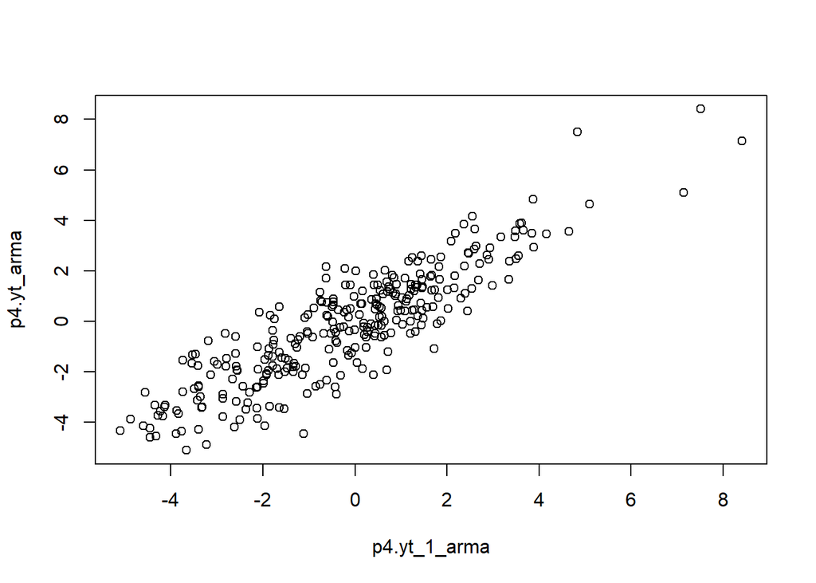

```r
plot(y=p4.yt_arma,x=p4.yt_1_arma)
```

Berdasarkan scatterplot tersebut, terlihat bahwa terdapat hubungan positif antara $Y_t$ dengan $Y_{t-1}$.

```r
cor(p4.yt_arma,p4.yt_1_arma)
```

```
## [1] 0.879793
```

#### $Y_t$ dengan $Y_{t-2}$

```r
p4.yt_arma2 <- p4.arma11[-c(1,2)]
p4.yt_arma2
```

```
##   [1]  0.4005235183  1.8622074218  2.5547686781  4.1623885176  3.4690332727
##   [6]  3.3467946531  1.6633419370  1.8208957582  2.1621398450  1.8135278780
##  [11]  0.9452626712  0.6368881680 -0.5601812864 -1.1122684372 -4.4551413433
##  [16] -4.2326533850 -3.5505742888 -1.6595796313 -2.1154019323 -1.0183412356
##  [21] -0.4723166796  0.8843545133  1.0854486996  1.6984175647  0.5661556748
##  [26]  0.5324942865  0.5889881229  0.1939316939 -0.0812854382 -1.2615838763
##  [31] -1.0384531015 -2.8702126708 -2.8767388658 -3.7639862701 -4.3493636272
##  [36] -3.3221555297 -3.4003484019 -2.5975406557 -1.2840067565 -1.7851656419
##  [41] -0.3682631716  0.4567786849  0.6883429489  1.5626740290  0.5431184972
##  [46]  1.2169124052  1.4762904064  0.1210663290  0.6967459877 -1.9279351337
##  [51] -2.1173367764 -2.5878869784 -1.7759151721 -0.9145728816 -0.6210539015
##  [56]  0.2376446983 -1.0374019519 -0.4112312247 -0.4271214636 -2.5904816046
##  [61] -0.6030640662  0.7344836264  1.3650739819  2.3849460972  2.1767971177
##  [66]  3.4972682218  2.4687482536  2.6870368717  1.6434113469  1.7835077282
##  [71] -0.1049948082  1.4533355269  0.4381586533  0.4845938907  0.6439873399
```

[output cut: 45 more lines]

```r
#Yt-2
p4.yt_2_arma <- p4.arma11[-c(299,300)]
p4.yt_2_arma
```

```
##   [1]  0.6056187577  1.0920911072  0.4005235183  1.8622074218  2.5547686781
##   [6]  4.1623885176  3.4690332727  3.3467946531  1.6633419370  1.8208957582
##  [11]  2.1621398450  1.8135278780  0.9452626712  0.6368881680 -0.5601812864
##  [16] -1.1122684372 -4.4551413433 -4.2326533850 -3.5505742888 -1.6595796313
##  [21] -2.1154019323 -1.0183412356 -0.4723166796  0.8843545133  1.0854486996
##  [26]  1.6984175647  0.5661556748  0.5324942865  0.5889881229  0.1939316939
##  [31] -0.0812854382 -1.2615838763 -1.0384531015 -2.8702126708 -2.8767388658
##  [36] -3.7639862701 -4.3493636272 -3.3221555297 -3.4003484019 -2.5975406557
##  [41] -1.2840067565 -1.7851656419 -0.3682631716  0.4567786849  0.6883429489
##  [46]  1.5626740290  0.5431184972  1.2169124052  1.4762904064  0.1210663290
##  [51]  0.6967459877 -1.9279351337 -2.1173367764 -2.5878869784 -1.7759151721
##  [56] -0.9145728816 -0.6210539015  0.2376446983 -1.0374019519 -0.4112312247
##  [61] -0.4271214636 -2.5904816046 -0.6030640662  0.7344836264  1.3650739819
##  [66]  2.3849460972  2.1767971177  3.4972682218  2.4687482536  2.6870368717
##  [71]  1.6434113469  1.7835077282 -0.1049948082  1.4533355269  0.4381586533
```

[output cut: 45 more lines]

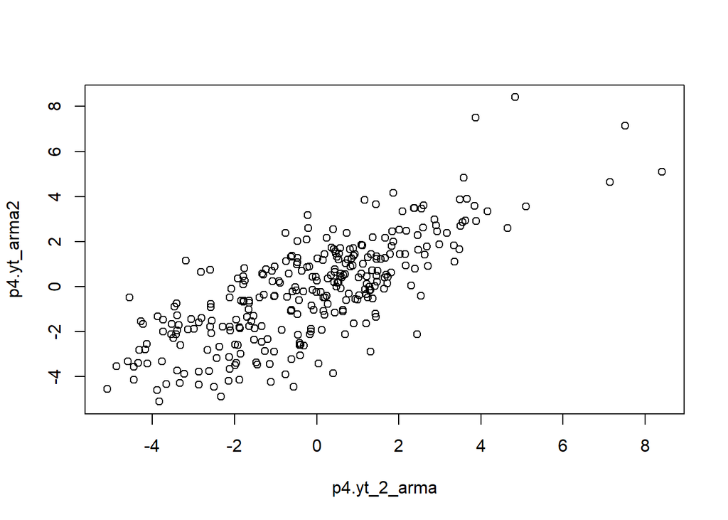

```r
plot(y=p4.yt_arma2,x=p4.yt_2_arma)
```

Berdasarkan scatterplot tersebut, terlihat bahwa terdapat hubungan positif antara $Y_t$ dengan $Y_{t-2}$.

```r
cor(p4.yt_arma2,p4.yt_2_arma)
```

```
## [1] 0.7552331
```

#### $Y_t$ dengan $Y_{t-3}$

```r
p4.yt_arma3 <- p4.arma11[-c(1,2,3)]
p4.yt_arma3
```

```
##   [1]  1.8622074218  2.5547686781  4.1623885176  3.4690332727  3.3467946531
##   [6]  1.6633419370  1.8208957582  2.1621398450  1.8135278780  0.9452626712
##  [11]  0.6368881680 -0.5601812864 -1.1122684372 -4.4551413433 -4.2326533850
##  [16] -3.5505742888 -1.6595796313 -2.1154019323 -1.0183412356 -0.4723166796
##  [21]  0.8843545133  1.0854486996  1.6984175647  0.5661556748  0.5324942865
##  [26]  0.5889881229  0.1939316939 -0.0812854382 -1.2615838763 -1.0384531015
##  [31] -2.8702126708 -2.8767388658 -3.7639862701 -4.3493636272 -3.3221555297
##  [36] -3.4003484019 -2.5975406557 -1.2840067565 -1.7851656419 -0.3682631716
##  [41]  0.4567786849  0.6883429489  1.5626740290  0.5431184972  1.2169124052
##  [46]  1.4762904064  0.1210663290  0.6967459877 -1.9279351337 -2.1173367764
##  [51] -2.5878869784 -1.7759151721 -0.9145728816 -0.6210539015  0.2376446983
##  [56] -1.0374019519 -0.4112312247 -0.4271214636 -2.5904816046 -0.6030640662
##  [61]  0.7344836264  1.3650739819  2.3849460972  2.1767971177  3.4972682218
##  [66]  2.4687482536  2.6870368717  1.6434113469  1.7835077282 -0.1049948082
##  [71]  1.4533355269  0.4381586533  0.4845938907  0.6439873399 -0.0003705921
```

[output cut: 45 more lines]

```r
#Yt-2
p4.yt_3_arma <- p4.arma11[-c(298,299,300)]
p4.yt_3_arma
```

```
##   [1]  0.6056187577  1.0920911072  0.4005235183  1.8622074218  2.5547686781
##   [6]  4.1623885176  3.4690332727  3.3467946531  1.6633419370  1.8208957582
##  [11]  2.1621398450  1.8135278780  0.9452626712  0.6368881680 -0.5601812864
##  [16] -1.1122684372 -4.4551413433 -4.2326533850 -3.5505742888 -1.6595796313
##  [21] -2.1154019323 -1.0183412356 -0.4723166796  0.8843545133  1.0854486996
##  [26]  1.6984175647  0.5661556748  0.5324942865  0.5889881229  0.1939316939
##  [31] -0.0812854382 -1.2615838763 -1.0384531015 -2.8702126708 -2.8767388658
##  [36] -3.7639862701 -4.3493636272 -3.3221555297 -3.4003484019 -2.5975406557
##  [41] -1.2840067565 -1.7851656419 -0.3682631716  0.4567786849  0.6883429489
##  [46]  1.5626740290  0.5431184972  1.2169124052  1.4762904064  0.1210663290
##  [51]  0.6967459877 -1.9279351337 -2.1173367764 -2.5878869784 -1.7759151721
##  [56] -0.9145728816 -0.6210539015  0.2376446983 -1.0374019519 -0.4112312247
##  [61] -0.4271214636 -2.5904816046 -0.6030640662  0.7344836264  1.3650739819
##  [66]  2.3849460972  2.1767971177  3.4972682218  2.4687482536  2.6870368717
##  [71]  1.6434113469  1.7835077282 -0.1049948082  1.4533355269  0.4381586533
```

[output cut: 45 more lines]

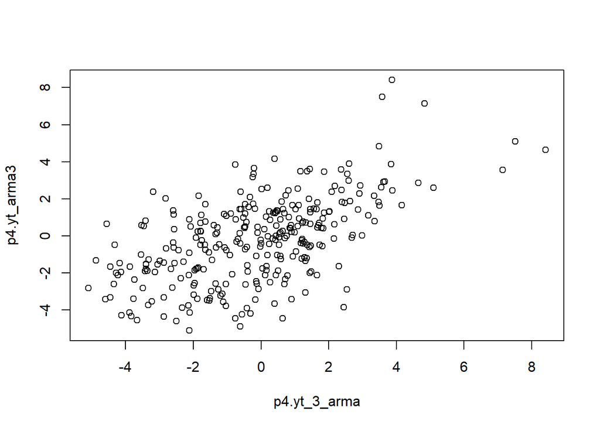

```r
plot(y=p4.yt_arma3,x=p4.yt_3_arma)
```

Berdasarkan scatterplot tersebut, terlihat bahwa terdapat hubungan positif antara $Y_t$ dengan $Y_{t-3}$.

```r
cor(p4.yt_arma3,p4.yt_3_arma)
```

```
## [1] 0.5726778
```